# Species Segmentation with Cluster Analysis

The Iris flower dataset is one of the most popular ones for machine learning. You can read a lot about it online and have probably already heard of it: https://en.wikipedia.org/wiki/Iris_flower_data_set

We didn't want to use it in the lectures, but believe that it would be very interesting for you to try it out (and maybe read about it on your own).

There are 4 features: sepal length, sepal width, petal length, and petal width.

Start by creating 2 clusters. Then standardize the data and try again. Does it make a difference?

Use the Elbow rule to determine how many clusters are there.

## Import the relevant libraries

```python
import pandas as pd
import numpy as np
import seaborn as sns
from sklearn.cluster import KMeans
import matplotlib.pyplot as plt
sns.set()
```

## Load the data

Load data from the csv file: *'iris_dataset.csv'*.

```python
data = pd.read_csv('iris-dataset.csv')
datalw=data.drop(['petal_length','petal_width'],axis=1)
datalw
```

|  | sepal_length | sepal_width |
| --- | --- | --- |
| 0 | 5.1 | 3.5 |
| 1 | 4.9 | 3.0 |
| 2 | 4.7 | 3.2 |
| 3 | 4.6 | 3.1 |
| 4 | 5.0 | 3.6 |
| ... | ... | ... |
| 145 | 6.7 | 3.0 |
| 146 | 6.3 | 2.5 |
| 147 | 6.5 | 3.0 |
| 148 | 6.2 | 3.4 |
| 149 | 5.9 | 3.0 |

150 rows × 2 columns

## Plot the data

For this exercise, try to cluster the iris flowers by the shape of their sepal.

*Use the 'sepal_length' and 'sepal_width' variables.*

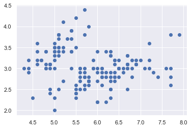

```python
plt.scatter(data['sepal_length'],data['sepal_width'],cmap='rainbow')
plt.xlabel='Sepal Length'
plt.ylabel='Sepal Width'
plt.show()
```

# Clustering (unscaled data)

Separate the original data into 2 clusters.

```python
kmeans=KMeans(2)
```

```python
kmeans.fit(datalw)
cluster=data.copy()
cluster['clusterpred']=kmeans.fit_predict(datalw)
```

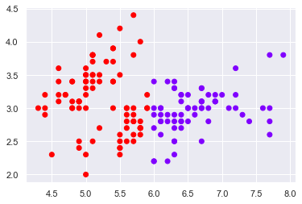

```python
plt.scatter(cluster['sepal_length'],cluster['sepal_width'],c=cluster['clusterpred'],cmap='rainbow')
plt.xlabel='Sepal Length'
plt.ylabel='Sepal Width'
plt.show()
```

# Standardize the variables

Import and use the *method* function from sklearn to standardize the data.

```python
from sklearn.preprocessing import scale
datascaled=scale(datalw)
```

# Clustering (scaled data)

```python
kmscaled=KMeans(5)
kmscaled.fit(datascaled)
clusterscaled=datalw.copy()
clusterscaled['cluster']=kmscaled.fit_predict(datascaled)
```

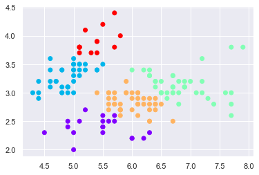

```python
plt.scatter(clusterscaled['sepal_length'],clusterscaled['sepal_width'],c=clusterscaled['cluster'],cmap='rainbow')
plt.xlabel='Sepal Length'
plt.ylabel='Sepal Width'
plt.show()
```

## Take Advantage of the Elbow Method

### WCSS

```python
wcss = []

for i in range(1,10):
    kmeans=KMeans(i)
    kmeans.fit(datascaled)
    wcss.append(kmeans.inertia_)
wcss
```

```
[300.00000000000006,
 168.39262198361095,
 103.78443895265744,
 79.71916925065548,
 61.70659834761936,
 52.12057513457867,
 44.03401663876659,
 36.228586288894256,
 31.27150769143909]
```

### The Elbow Method

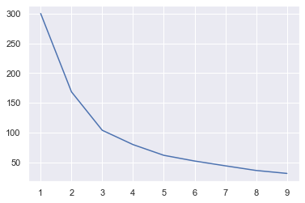

```python
plt.plot(range(1,10),wcss)
plt.xlabel='n of clusters'
plt.ylabel='wcss'
```

How many clusters are there?